# Bayesian_Binom_and_MRP_hierarchical_raking_softmax_Poisson_NeosphereB_discont

## Import packages

Package installations are collected in different notebook.

```python
import numpy as np
import pandas as pd
from sklearn.preprocessing import StandardScaler
import arviz as az
import seaborn as sns
import matplotlib.pyplot as plt
from scipy.special import expit
import pymc as pm
import ipywidgets
import pytensor as pt
import graphviz
from scipy.stats import norm, t
#import openpyxl
from collections import Counter
from statistics import harmonic_mean
import pytensor.tensor as pt
import re
import itertools
from scipy.stats import beta
```

```python
run_model = False
```

```python
%run /mnt/batch/tasks/shared/LS_root/mounts/clusters/hus555425151/code/Users/Per_Tra_analysis/common_functions.py
```

```python
%run /mnt/batch/tasks/shared/LS_root/mounts/clusters/hus555425151/code/Users/Per_Tra_analysis/RCT_marginals.py
```

## Configurations

```python
%config InlineBackend.figure_format = 'retina'
az.style.use("arviz-whitegrid")
rng = np.random.default_rng(1234)
```

## Import data

```python
prefix_path = "/mnt/batch/tasks/shared/LS_root/mounts/clusters/hus555425151/code/"
per_tra = pd.read_csv(prefix_path + "Users/Per_Tra_analysis/per_tra_master_final.csv", sep=",")
NAT_neosphere_discont_comp = pd.read_csv(prefix_path + "Users/Per_Tra_analysis/Data/NAT_neosphere_discont_comp.csv", sep=",").rename(columns={"person_id":"Pseudo"})
per_tra = (per_tra
           .merge(NAT_neosphere_discont_comp
                  , on = "Pseudo"
                  , how = "left"
                 )
          )

per_tra["NAT_discontinuation"] = per_tra["finished_NAT"].map({True: False, False: True})
```

## Data wrangling

### Redefine variables

Each RCT has different table 1 and the variables hove to be modified accordingly. This is done with the data_wrangling function. Then the model variables are collected, factorized, the mapping are saved and put in the dictionaries so that they are easy to hande in the model.

```python
per_tra = data_wrangling(per_tra, target="Neosphere")


X_age = per_tra["Age_group_med"]
X_Node_cytology_preop = per_tra["Node_cytology_preop"]
X_Tumor_size_class_preop = per_tra['Tumor_size_class_preop']
X_hormone_status = per_tra["hormone_status"]
X_bilateral = per_tra["Bilateral"]
X_NAT_discontinuation = per_tra["NAT_discontinuation"]
y = per_tra["pCR_or_not"]

age_idx, age_groups = pd.factorize(X_age, sort=True)
Node_cytology_preop_idx, Node_cytology_preop_groups = pd.factorize(X_Node_cytology_preop, sort=True)
Tumor_size_class_preop_idx, Tumor_size_class_preop_groups = pd.factorize(X_Tumor_size_class_preop, sort=True)
hormone_status_idx, hormone_status_groups = pd.factorize(X_hormone_status, sort=True)
bilateral_idx, bilateral_groups = pd.factorize(X_bilateral, sort=True)
NAT_discontinuation_idx, NAT_discontinuation_groups = pd.factorize(X_NAT_discontinuation, sort=True)


age_map = {cat: i for i, cat in enumerate(age_groups)}
Node_cytology_preop_map = {cat: i for i, cat in enumerate(Node_cytology_preop_groups)}
Tumor_size_class_preop_map = {cat: i for i, cat in enumerate(Tumor_size_class_preop_groups)}
hormone_status_map = {cat: i for i, cat in enumerate(hormone_status_groups)}
bilateral_map = {cat: i for i, cat in enumerate(bilateral_groups)}
NAT_discontinuation_map = {cat: i for i, cat in enumerate(NAT_discontinuation_groups)}


pCR_idx, pCR_groups = pd.factorize(y, sort=True)

coords = {"Age_group_med": age_groups
          , "Node_cytology_preop": Node_cytology_preop_groups
          , "Tumor_size_class_preop": Tumor_size_class_preop_groups
          , "hormone_status":hormone_status_groups
          , "Bilateral":bilateral_groups
          , "NAT_discontinuation":NAT_discontinuation_groups

          #, "observations": pCR_idx
         }

idx_dict = {"Age_group_med": age_idx
          , "Node_cytology_preop": Node_cytology_preop_idx
          , "Tumor_size_class_preop": Tumor_size_class_preop_idx
          , "hormone_status":hormone_status_idx
          , "Bilateral":bilateral_idx
            , "NAT_discontinuation":NAT_discontinuation_idx
          }

# Make sure idx_dict[var] are plain int64 NumPy arrays (not Pandas, not object dtype)
idx_dict = {k: np.asarray(v, dtype="int64") for k, v in idx_dict.items()}
```

The model needs the contingency table and the loading matrix L for counting the marginals from the contingency table and they are created here. The raking sep also needs the variable indexies for the post-stratification, and they are provided here.

```python
raking_vars = list(coords.keys())
margin_formulas = [[x] for x in raking_vars]

L, poststrat_table, row_labels, col_labels, L_blocks = build_loading_matrix_from_data(data=per_tra, raking_vars=raking_vars, margin_formulas=margin_formulas, marg_dict=marginals_neosphereB_discont)

age_poststrat_idx = poststrat_table["Age_group_med"].map(age_map)
Node_cytology_preop_poststrat_idx = poststrat_table["Node_cytology_preop"].map(Node_cytology_preop_map)
Tumor_size_class_preop_poststrat_idx = poststrat_table["Tumor_size_class_preop"].map(Tumor_size_class_preop_map)
hormone_status_poststrat_idx = poststrat_table["hormone_status"].map(hormone_status_map)
bilateral_poststrat_idx = poststrat_table["Bilateral"].map(bilateral_map)
NAT_discontinuation_poststrat_idx = poststrat_table["NAT_discontinuation"].map(NAT_discontinuation_map)


idx_dict_postrat = {"Age_group_med": age_poststrat_idx
          , "Node_cytology_preop": Node_cytology_preop_poststrat_idx
          , "Tumor_size_class_preop": Tumor_size_class_preop_poststrat_idx
          , "hormone_status":hormone_status_poststrat_idx
          , "Bilateral":bilateral_poststrat_idx
          , "NAT_discontinuation":NAT_discontinuation_poststrat_idx
         }
```

The zero marginal rows (normally coming from the exclusion/inclusion criteria) are not needed because post-stratification should give the probability zero. We also want that the marginals are in the same order as the loading matrix L gives them, and the order is set here.

```python
marginals_neosphereB_discont_trunc = {k:v for k,v in marginals_neosphereB_discont.items() if v != 0}
marginals_neosphereB_discont_trunc = {i:marginals_neosphereB_discont_trunc[i] for i in row_labels}
```

## Parameters and data to the model

The model needs the contingency table's number vector N_org, target marginal blocks N_target_marginal_blocks, contingency table's vector's length C, number of marginal blocks to iterate over B, the sample size of the row-level data T_org, target N T_target, logarithmitized and normalized contingency vector log_q, pCR counts from both HUS and the RCT, and the comparison table from the pCR counts for the binomial model.

```python
# ---- Provide your data here ----
# N_org: (C,), N_marg: (K,), L: (K,C)
N_org   = poststrat_table["Freq"].to_numpy()
N_target_marg_blocks = marg_dict_to_blocks(marginals_neosphereB_discont_trunc)
eps     = 1e-8

C = N_org.shape[0]
B = len(L_blocks)
T_org = int(N_org.sum())
T_target  = N_neosphereB

# Original composition with epsilon-floor
q = N_org / T_org
q_star = np.maximum(q, eps)
q_star = q_star / q_star.sum()
log_q = np.log(np.maximum(q_star, 1e-12))

N_pCR_HUS = len(y[y==True])


#Combine the results in one table
comparison_table = pd.DataFrame([{"source":"Neosphere", "pCR_count":N_pCR_neosphereB, "count":N_neosphereB}, {"source":"HUS", "pCR_count":N_pCR_HUS, "count":len(y)}])

source = comparison_table["source"]
count = comparison_table["count"]
pCR_count = comparison_table["pCR_count"]

source_idx, source_groups = pd.factorize(source)
```

## The Model

Checking the model parameter dimensions and then defining the model.

```python
print("coords:", coords)
print("post_idx shapes:", {k: len(v) for k, v in idx_dict_postrat.items()})
print("N_target_marg_blocks lengths:", [len(b) for b in N_target_marg_blocks])
print("Loading matrices shapes:", [Lb.shape for Lb in L_blocks])
```

```
coords: {'Age_group_med': CategoricalIndex(['Under 50', '50 - 77', 'Over 77'], categories=['Under 50', '50 - 77', 'Over 77'], ordered=True, dtype='category'), 'Node_cytology_preop': Index(['N/A', 'neg', 'pos'], dtype='object'), 'Tumor_size_class_preop': CategoricalIndex(['T1', 'T2', 'T3', 'N/A'], ca…
post_idx shapes: {'Age_group_med': 32, 'Node_cytology_preop': 32, 'Tumor_size_class_preop': 32, 'hormone_status': 32, 'Bilateral': 32, 'NAT_discontinuation': 32}
N_target_marg_blocks lengths: [2, 2, 2, 2, 1, 2]
Loading matrices shapes: [(2, 32), (2, 32), (2, 32), (2, 32), (1, 32), (2, 32)]
```

```python
with pm.Model(coords=coords) as binom_mrp_rake_softmax_poisson:

    # ----------------------------
    # 1) Outcome model (hierarchical ANOVA logit)
    # ----------------------------
    # Global intercept
    beta0 = pm.Normal("beta0", 0.0, 1.5)

    # global slab scale for all factors
    g_beta = pm.HalfNormal("g_beta", sigma=0.7)

    # Factor level effects: Student-t(ν=4, 0, τ_k) with sum-to-zero within each factor
    beta_levels = {}
    for var, val in coords.items():
        # per-factor scale (gentle partial pooling)
        tau_var = pm.HalfNormal(f"tau_{var}", sigma=g_beta)

        # Uncentered raw effects
        #beta_raw = pm.StudentT(f"beta_raw_{var}", nu=4, mu=0.0, sigma=tau_dict[var], dims=var)
        beta_raw = pm.StudentT(f"beta_raw_{var}", nu=4, mu=0.0, sigma=tau_var, dims=var)
        # Enforce sum-to-zero across levels
        beta_k = pm.Deterministic(f"beta_{var}", beta_raw - pm.math.mean(beta_raw), dims=var)
        beta_levels[var] = beta_k

    # Linear predictor per person i: beta0 + sum_k beta_{k, idx_k[i]}
    # Gather all additive parts
    terms_outcome = [beta0] + [pt.take(beta_levels[var], idx_dict[var]) for var in coords.keys()]

    # Sum safely in one operation
    eta_outcome_i = pt.add(*terms_outcome)
    p_outcome_i = pm.Deterministic("p_outcome_i", pm.math.sigmoid(eta_outcome_i))

    # Outcome likelihood
    pm.Bernoulli("y", p=p_outcome_i, observed=pCR_idx)

    # ----------------------------
    # 2) Bayesian raking over joint cells
    # ----------------------------

    dev_scale = pm.HalfNormal("dev_scale", sigma=0.3)

    # ANOVA-style deviations per factor
    dev_cell = 0
    for var in coords.keys():
        # raw deviations per level
        dev_raw  = pm.Normal(
            f"dev_{var}_raw",
            mu=0.0,
            sigma=1.0,
            dims=var,
        )
        # sum-to-zero across levels
        dev_centered = dev_raw  - pm.math.mean(dev_raw )

        # map to poststrat cells
        dev_cell_var = dev_centered[idx_dict_postrat[var]]
        dev_cell = dev_cell + dev_scale * dev_cell_var


    eta_raw = log_q + dev_cell

    # remove additive non-identifiability
    eta = eta_raw - pm.math.mean(eta_raw)

    p_comp = pm.Deterministic("p_comp", pm.math.softmax(eta))

    Nhat = pm.Deterministic("Nhat", T_target * p_comp)


    # Poisson margins
    for b, (Lb, N_b) in enumerate(zip(L_blocks, N_target_marg_blocks)):
        mu_b = (pt.dot(Lb, Nhat) + eps)
        pm.Poisson(f"N_target_b{b}", mu=mu_b, observed=N_b)
    # ----------------------------
    # 3) Cell-level outcome probabilities
    # ----------------------------
    # Gather all additive parts
    terms_poststrat = [beta0] + [pt.take(beta_levels[var], idx_dict_postrat[var]) for var in coords.keys()]


    # Sum safely in one operation
    eta_poststrat_i = pt.add(*terms_poststrat)
    p_poststrat_i = pm.Deterministic("p_poststrat_i", pm.math.sigmoid(eta_poststrat_i))


    # ----------------------------
    # 4) Post-stratified estimands
    # ----------------------------
    # Overall target-population mean:
    theta_overall = pm.Deterministic("theta_overall", (p_poststrat_i * Nhat).sum() / Nhat.sum())

    # ----------------------------
    # 5) Binomial model for the observed pCR rates
    # ----------------------------
    # Uninformative beta priors
    binom_mrp_rake_softmax_poisson.add_coords({"source": source_groups})
    p_binom = pm.Beta("p_binom", alpha=1, beta=1, dims="source")

    #Difference between observed rates
    p_diff_obs = pm.Deterministic("p_diff_obs", p_binom[1]-p_binom[0])
    #Tähän asti ok
    #Likelihood
    pm.Binomial("pCR_count", n=count, p=p_binom, observed=pCR_count)

    #Difference between observed rates
    p_diff_counterfact = pm.Deterministic("p_diff_counterfact", p_binom[1]-theta_overall)
```

```python
if run_model:
    with binom_mrp_rake_softmax_poisson:
        idata = pm.sample( draws=3500
                           , tune=5500
                           #, target_accept=0.95
                           #, init="jitter+adapt_diag"
                           , chains = 3
                         , random_seed=rng)
        pm.sample_posterior_predictive(idata, extend_inferencedata=True, random_seed=rng)
        prior_samples = pm.sample_prior_predictive(100, random_seed=rng)
        pm.compute_log_likelihood(idata)
        az.to_netcdf(idata, prefix_path + "Users/Per_Tra_analysis/DATA/MCMC/binom_MRP_Raking_anova_softmax_neosphereb_discont.nc")
        az.to_netcdf(prior_samples, prefix_path + "Users/Per_Tra_analysis/DATA/MCMC/binom_MRP_Raking_anova_softmax_neosphereb_ppc_discont.nc")
else:
    idata = az.from_netcdf(prefix_path + "Users/Per_Tra_analysis/DATA/MCMC/binom_MRP_Raking_anova_softmax_neosphereb_discont.nc")
    prior_samples = az.from_netcdf(prefix_path + "Users/Per_Tra_analysis/DATA/MCMC/binom_MRP_Raking_anova_softmax_neosphereb_ppc_discont.nc")
```

# Prior Predictive Checks

Let's sample from the priors to check that they look as they should.

```python
# All prior random variables
all_prior_vars = list(prior_samples.prior.data_vars)

prior_beta_vars = [v for v in all_prior_vars if v.startswith("beta")]
print("Beta variables used in PPC:", prior_beta_vars)
```

```
Beta variables used in PPC: ['beta0', 'beta_raw_NAT_discontinuation', 'beta_Node_cytology_preop', 'beta_NAT_discontinuation', 'beta_hormone_status', 'beta_Tumor_size_class_preop', 'beta_raw_Bilateral', 'beta_raw_Node_cytology_preop', 'beta_raw_hormone_status', 'beta_raw_Age_group_med', 'beta_Bilater…
```

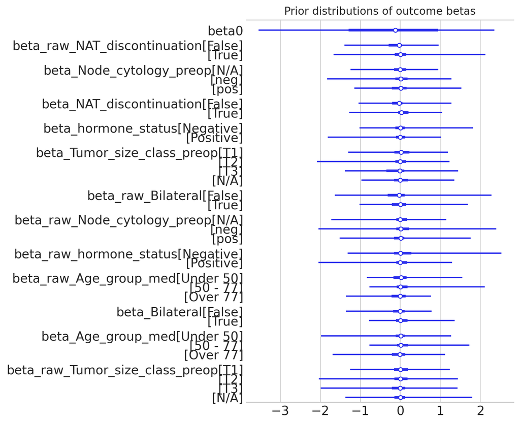

```python
def plot_prior_betas(prior_idata, beta_vars):
    """
    Plot prior distributions of all beta_* variables.
    """
    if not beta_vars:
        print("No beta_* variables found in prior.")
        return

    prior_idata_for_plot = prior_idata.copy()
    prior_idata_for_plot.posterior = prior_idata.prior

    az.plot_forest(
        prior_idata_for_plot,
        var_names=beta_vars,
        combined=True,  # combine chains
        figsize=(8, max(2, 0.5 * len(beta_vars))),
    )
    plt.title("Prior distributions of outcome betas", fontsize=12)
    plt.show()

plot_prior_betas(prior_samples, prior_beta_vars)
```

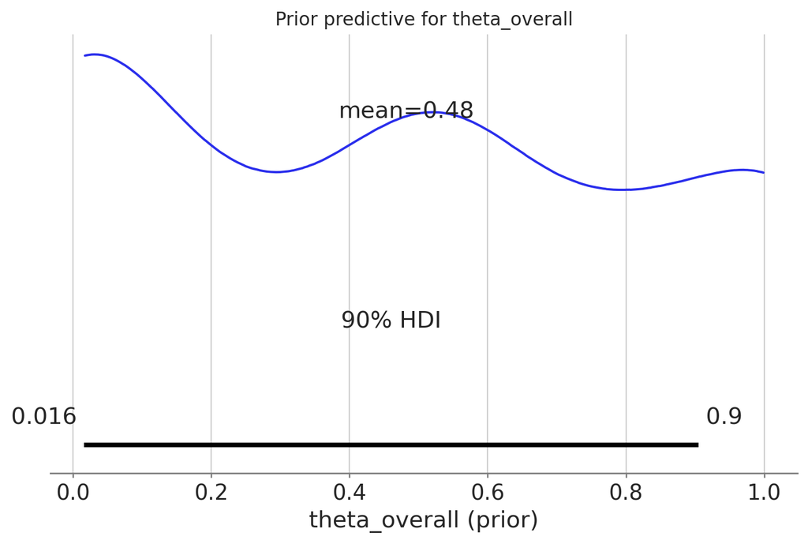

```python
def plot_prior_theta_overall(prior_idata):
    if "theta_overall" not in prior_idata.prior:
        print("theta_overall not found in prior_idata.prior")
        return

    prior_idata_for_plot = prior_idata.copy()
    prior_idata_for_plot.posterior = prior_idata.prior

    az.plot_posterior(
        prior_idata_for_plot,
        var_names=["theta_overall"],
        hdi_prob=0.9,
    )
    plt.title("Prior predictive for theta_overall", fontsize=12)
    plt.xlabel("theta_overall (prior)")
    plt.show()

plot_prior_theta_overall(prior_samples)
```

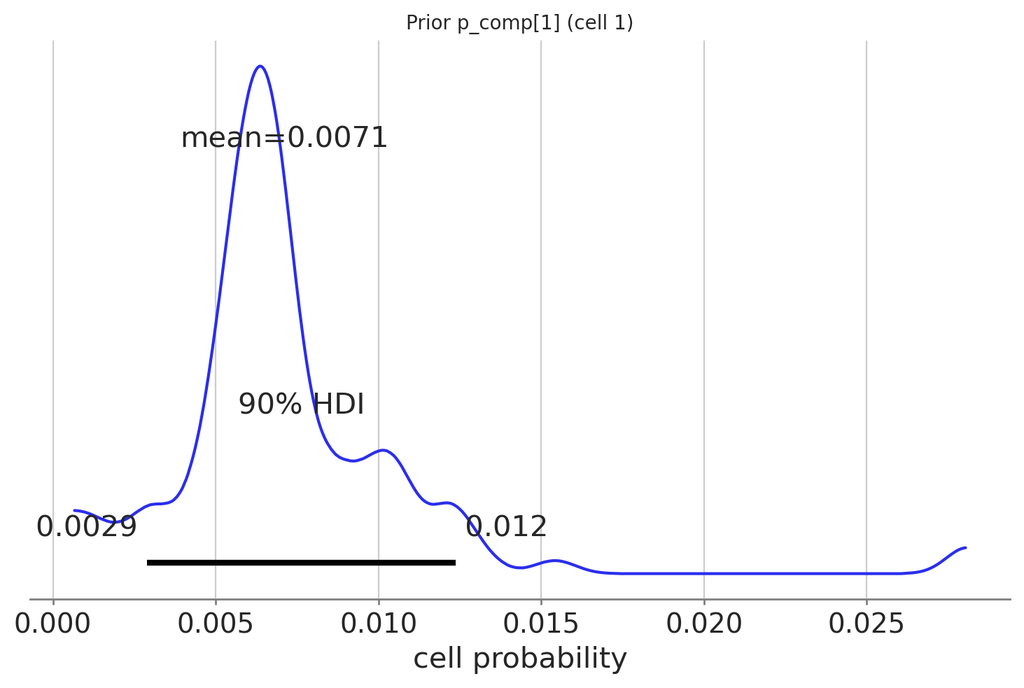

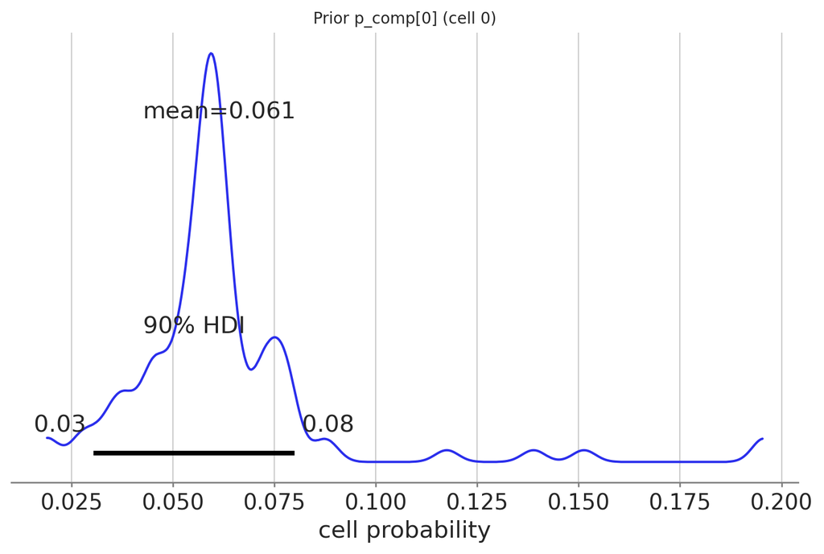

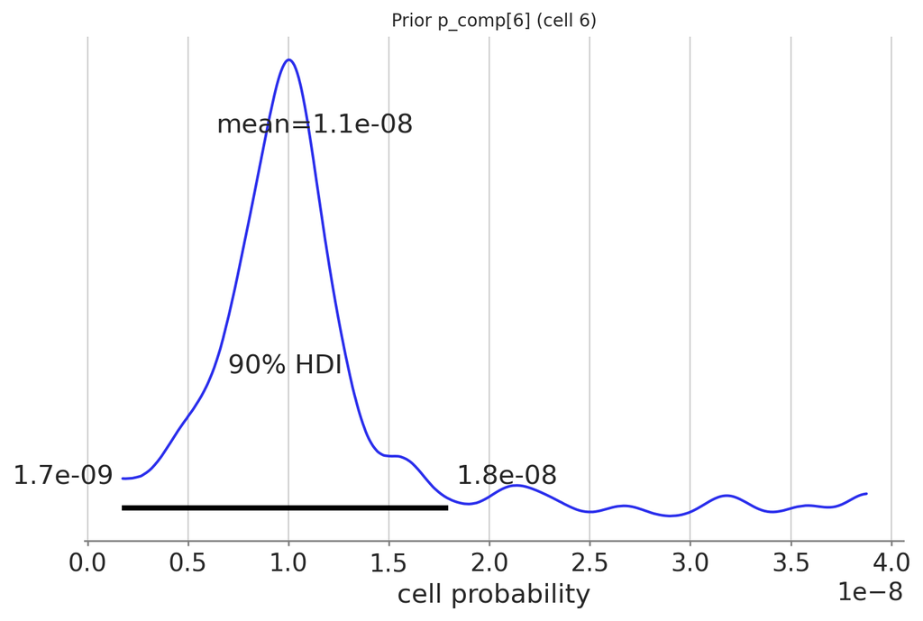

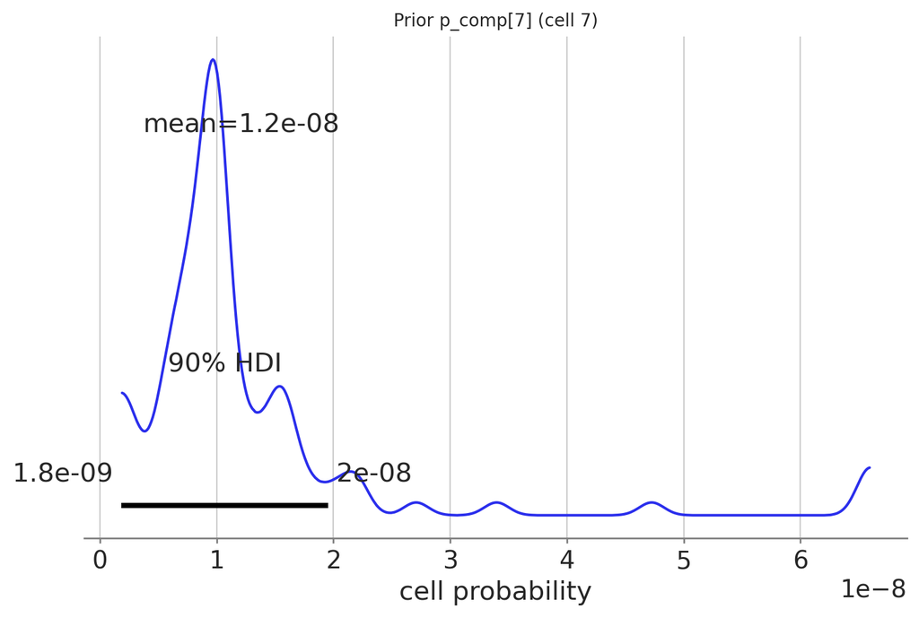

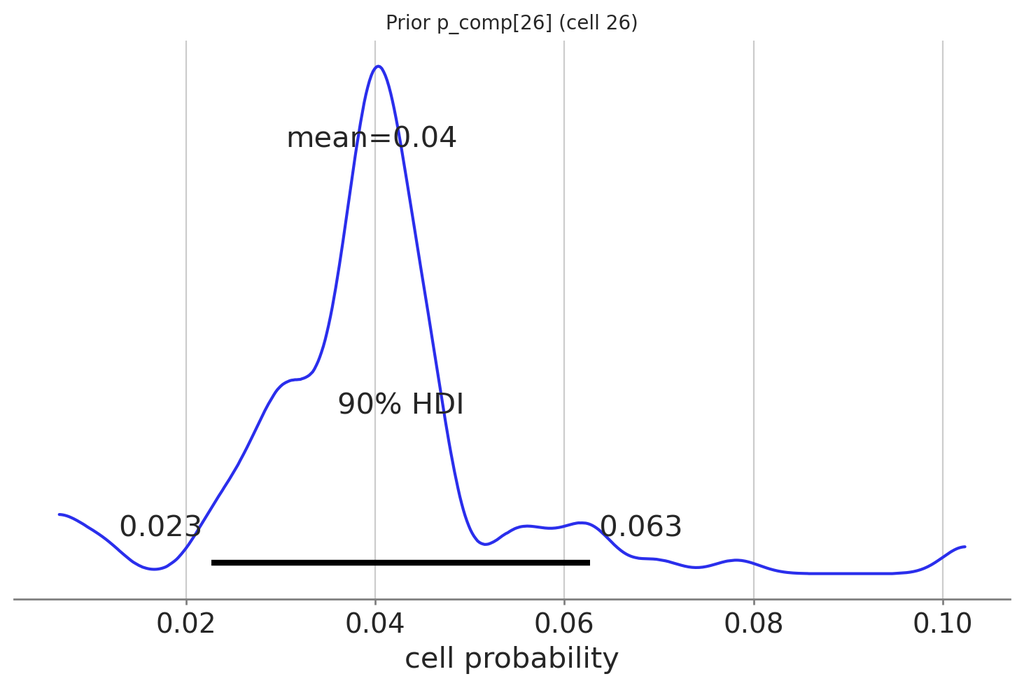

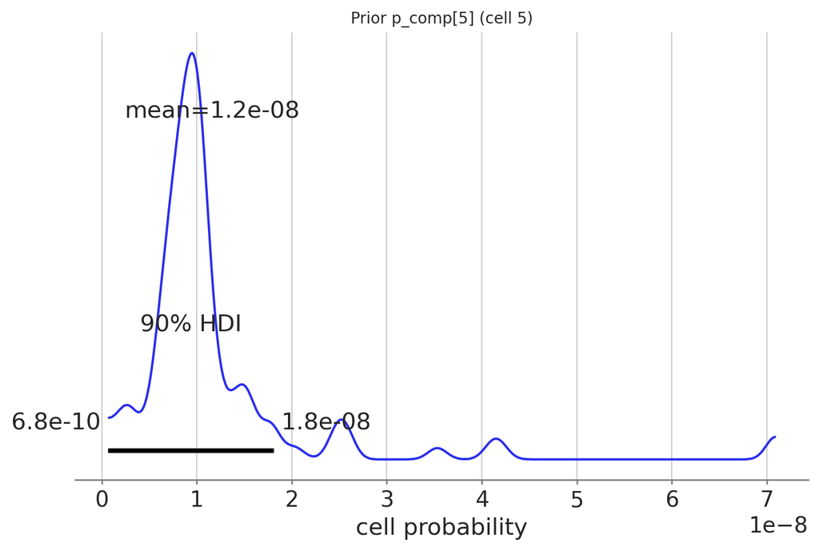

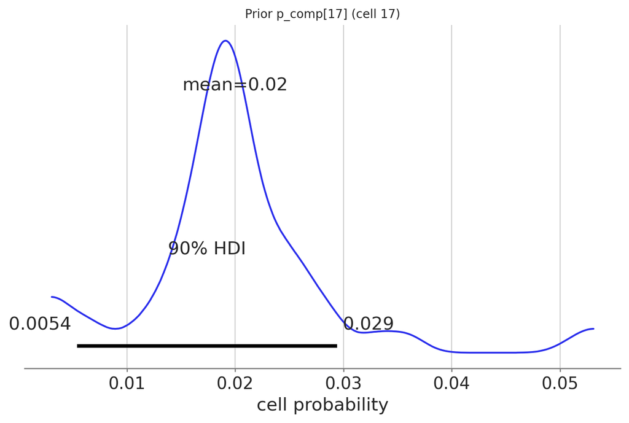

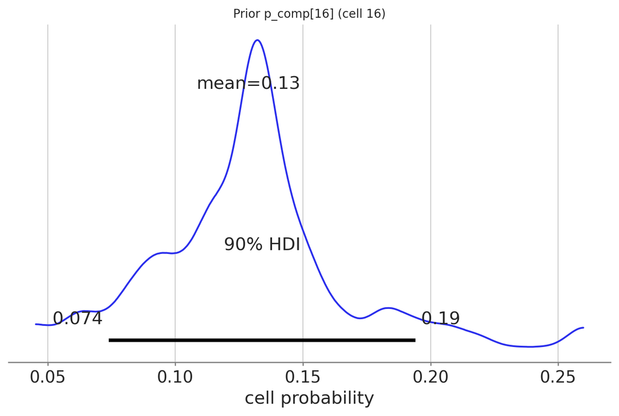

```python
def plot_prior_p_comp(prior_idata, n_cells_to_show=10):
    if "p_comp" not in prior_idata.prior:
        print("p_comp not found in prior_idata.prior")
        return


    p_prior = prior_idata.prior["p_comp"]  # shape: (chain, draw, C)
    C = p_prior.shape[-1]

    # Pick some random cell indices
    rng = np.random.default_rng(123)
    idx = rng.choice(C, size=min(n_cells_to_show, C), replace=False)

    for c in idx:
        samples = p_prior.sel(p_comp_dim_0=c).values.flatten()
        az.plot_posterior(samples, hdi_prob=0.9)
        plt.title(f"Prior p_comp[{c}] (cell {c})", fontsize=10)
        plt.xlabel("cell probability")
        plt.show()

plot_prior_p_comp(prior_samples, n_cells_to_show=8)
```

```python
def plot_prior_margins_from_Nhat(prior_idata, L_blocks, block_names=None, n_samples=200):
    """
    For each margin block, compute L_b @ Nhat for prior samples,
    and plot the prior predictive distribution of each margin level.
    """
    if "Nhat" not in prior_idata.prior:
        print("Nhat not found in prior_idata.prior")
        return

    Nhat_prior = prior_idata.prior["Nhat"]  # (chain, draw, C)
    chains, draws, C = Nhat_prior.shape

    # Stack chains & draws
    Nhat_flat = Nhat_prior.stack(sample=("chain", "draw")).values  # (C, S)
    S = Nhat_flat.shape[1]

    # Optionally limit number of samples for speed
    if S > n_samples:
        idx = np.random.default_rng(123).choice(S, Tumor_size_class_preop=n_samples, replace=False)
        Nhat_flat = Nhat_flat[:, idx]
        S = n_samples

    for b, Lb in enumerate(L_blocks):

        if Lb.shape[0] < 2:
            continue
        else:
            block_label = block_names[b] if block_names is not None else f"block {b}"

            # Nhat_b: (K_b, S)
            Nhat_b = Lb @ Nhat_flat

            K_b = Nhat_b.shape[0]
            print(f"\nPrior predictive margins for {block_label}:")

            for k in range(K_b):
                samples = Nhat_b[k, :]
                az.plot_posterior(samples, hdi_prob=0.9)
                plt.title(f"{block_label}, level {k} (prior predictive)", fontsize=10)
                plt.xlabel("Margin count")
                plt.show()
```

```
Prior predictive margins for block 0:
```

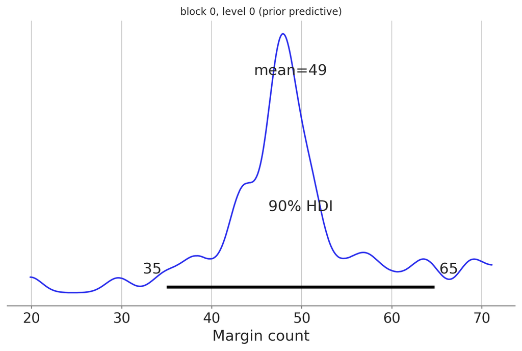

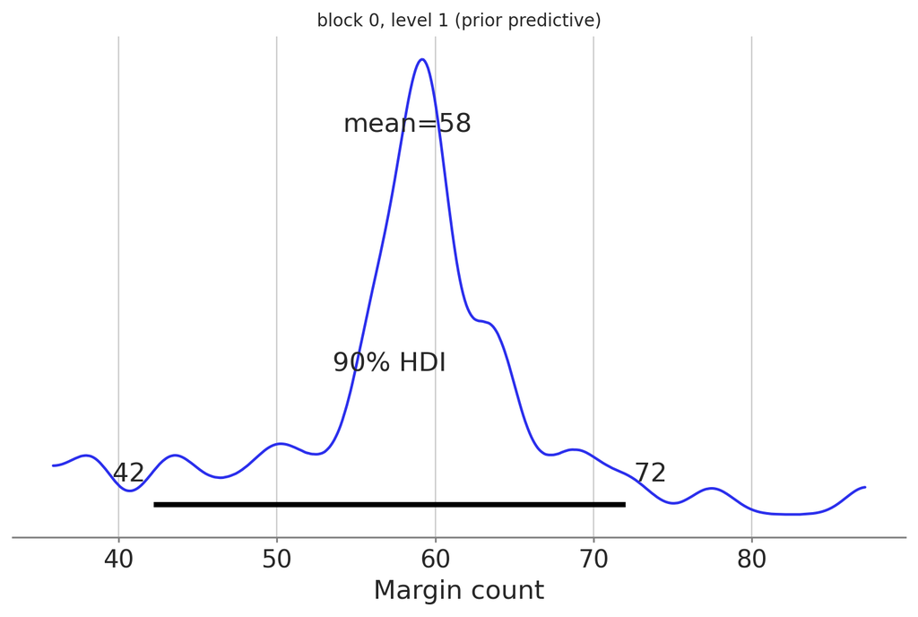

```
Prior predictive margins for block 1:
```

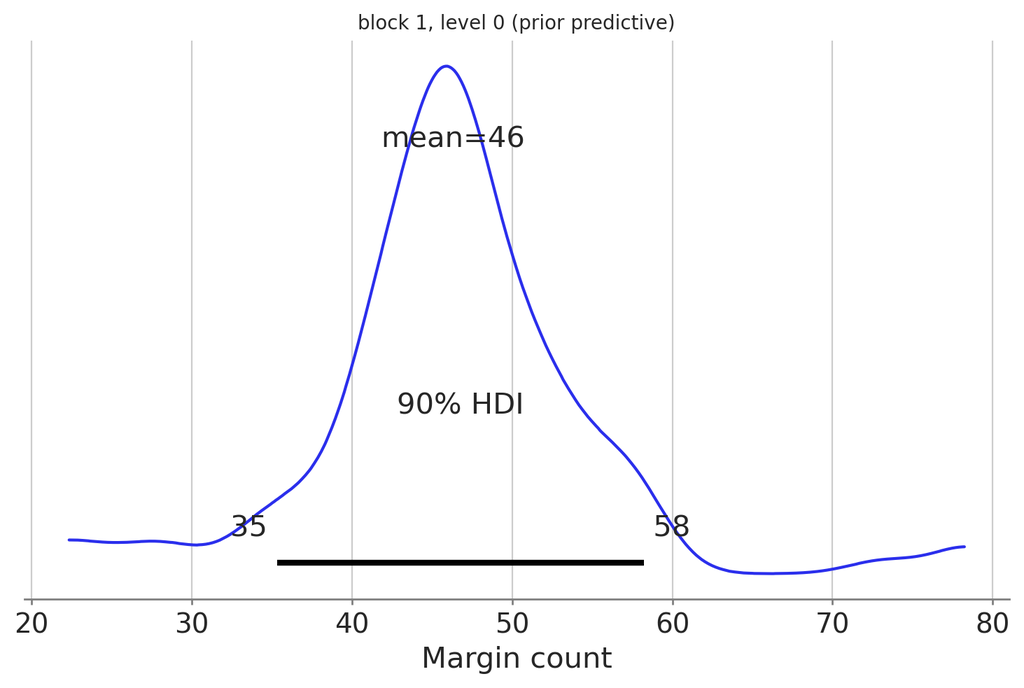

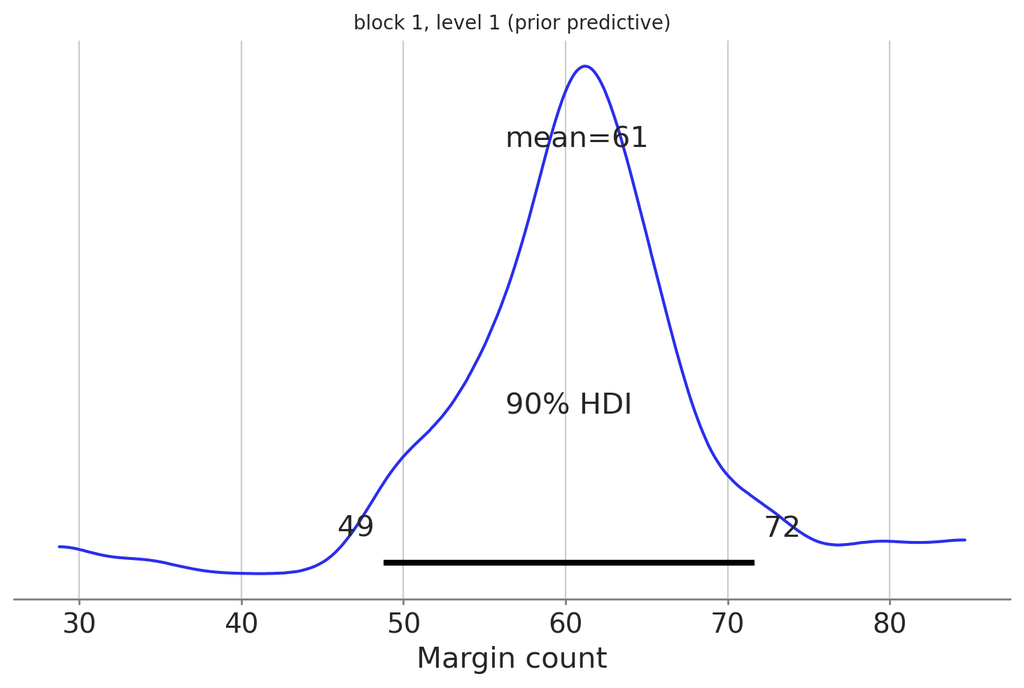

```
Prior predictive margins for block 2:
```

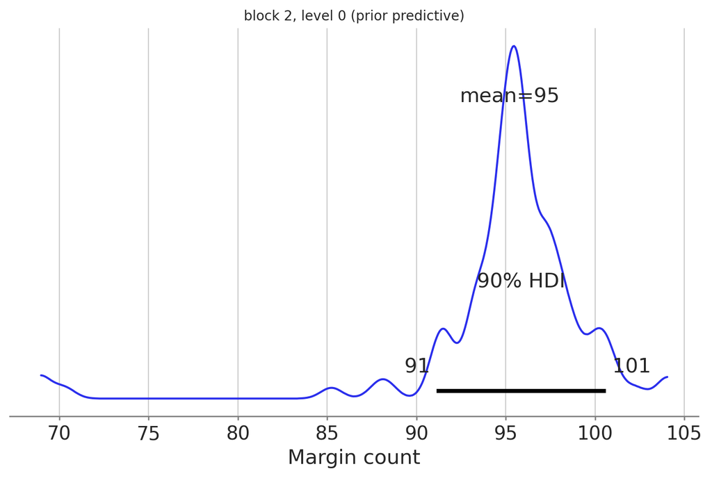

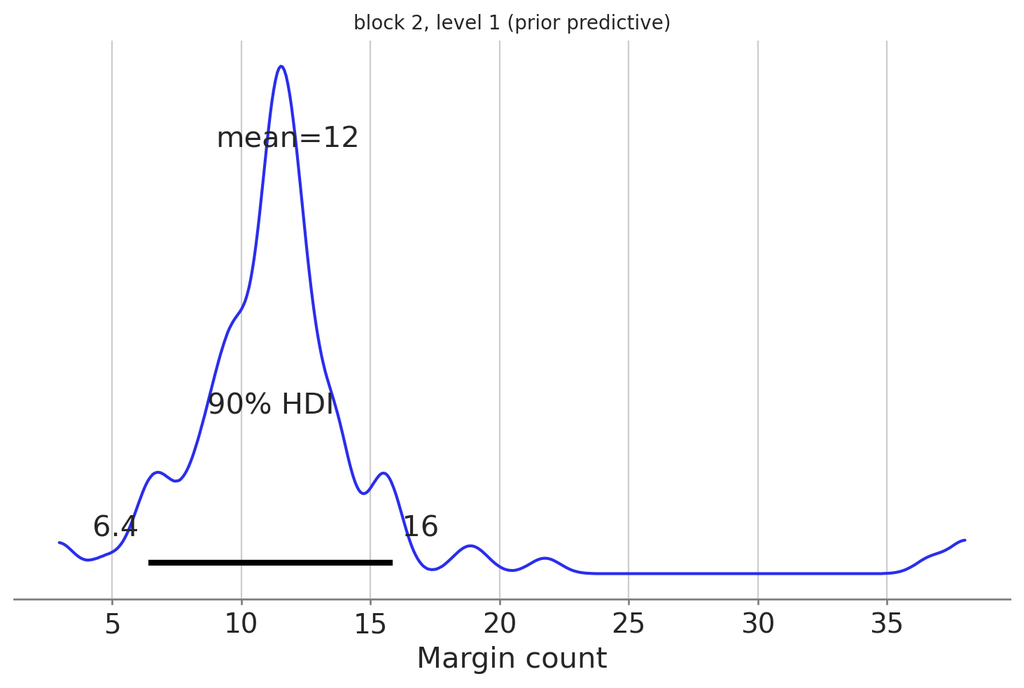

```
Prior predictive margins for block 3:
```

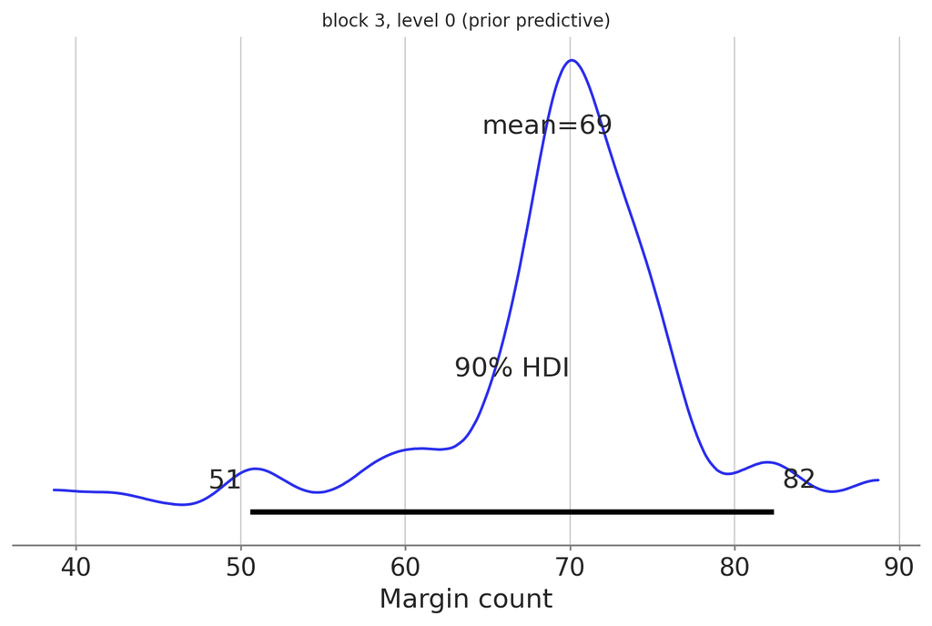

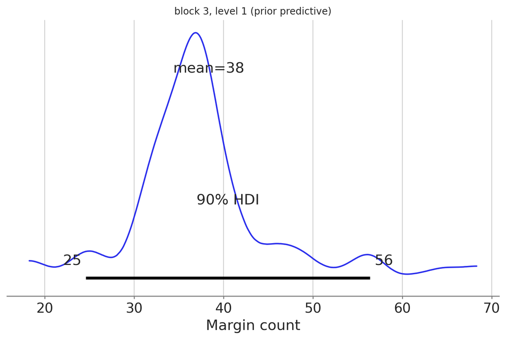

```
Prior predictive margins for block 5:
```

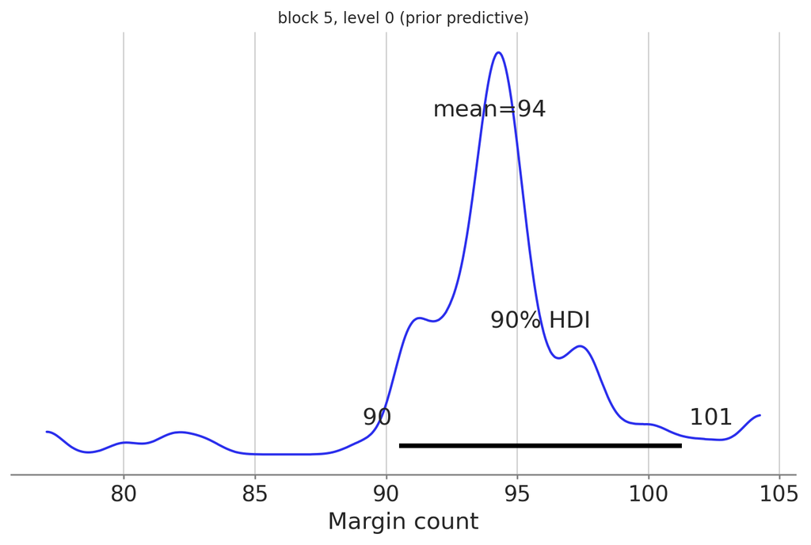

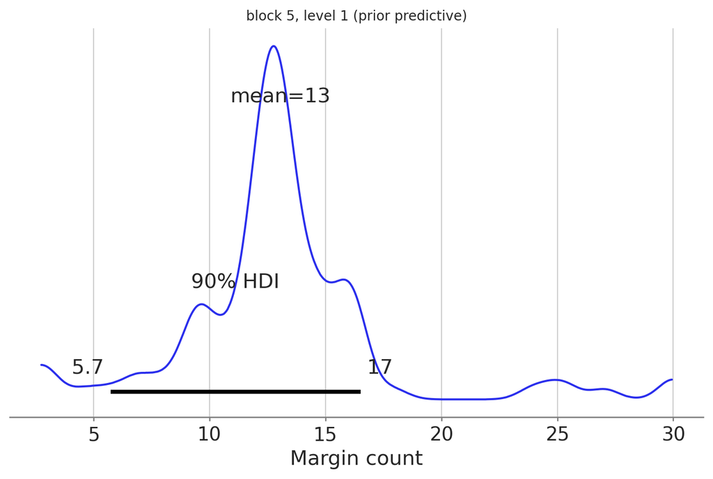

```python
plot_prior_margins_from_Nhat(prior_samples, L_blocks, block_names=None)
```

```python
row_labels
```

```
['Age_group_med:Under 50',
 'Age_group_med:50 - 77',
 'Node_cytology_preop:neg',
 'Node_cytology_preop:pos',
 'Tumor_size_class_preop:T2',
 'Tumor_size_class_preop:T3',
 'hormone_status:Negative',
 'hormone_status:Positive',
 'Bilateral:False',
 'NAT_discontinuation:False',
 'NAT_discontinuation:True']
```

## Diagnostics

Let's check that the MCMCs have converged and the BFMI is ok.

```python
dict_clear_var_names = {'beta_Age_group_med':'beta_age_group_med'
                        , 'beta_Node_cytology_preop':'beta_node_cytology_preop'
                        , 'beta_Tumor_size_class_preop':'beta_tumor_size_class_preop'
                        , 'beta_hormone_status':'beta_hormone_status_preop'
                        , 'beta_Bilateral':'beta_bilateral'
                        ,'beta_NAT_discontinuation':'beta_NAT_discontinuation'
}

idata_paper = idata.copy()  # cheap, doesn’t duplicate arrays
idata_paper = idata_paper.rename_vars(dict_clear_var_names)
```

```python
# Full list
all_vars = list(idata.posterior.data_vars)
print("All variables:", all_vars)

# Common groups
#core_vars = ["beta0", "g"]
core_vars = ["beta0"]
group_vars = [v for v in all_vars if v.startswith("tau_")]
effect_vars = [v for v in all_vars if v.startswith("beta_")]
rake_vars = ["eta", 'p_outcome_i']
theta_overall = ["theta_overall"]
nhat_vars = ['Nhat']
pCR_rate_vars = ["p_binom"]
pCR_rate_comp_vars = ["p_diff_obs", "p_diff_counterfact"]

#Renamed variables for the paper
all_vars_paper = list(idata_paper.posterior.data_vars)
effect_vars_paper = [v for v in all_vars_paper if (v.startswith("beta_")) & (~v.startswith("beta_raw"))]
```

```
All variables: ['beta0', 'beta_raw_Age_group_med', 'beta_raw_Node_cytology_preop', 'beta_raw_Tumor_size_class_preop', 'beta_raw_hormone_status', 'beta_raw_Bilateral', 'beta_raw_NAT_discontinuation', 'dev_Age_group_med_raw', 'dev_Node_cytology_preop_raw', 'dev_Tumor_size_class_preop_raw', 'dev_hormon…
```

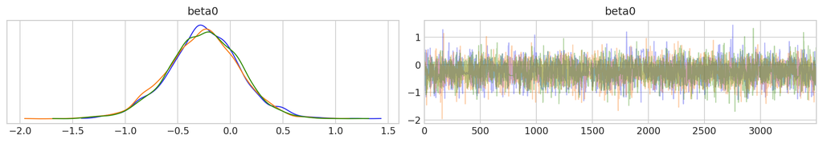

```python
az.plot_trace(idata, var_names=core_vars, compact=False);
```

[output not shown]

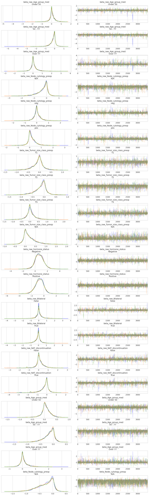

```python
az.plot_trace(idata, var_names=effect_vars, compact=False)
```

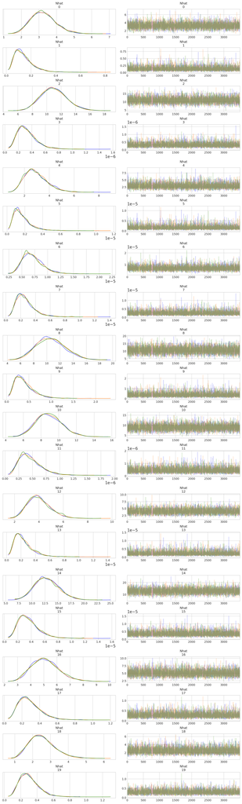

```python
az.plot_trace(idata, var_names=["Nhat"], compact=False);
```

```
array([[<Axes: title={'center': 'theta_overall'}>,
        <Axes: title={'center': 'theta_overall'}>]], dtype=object)
```

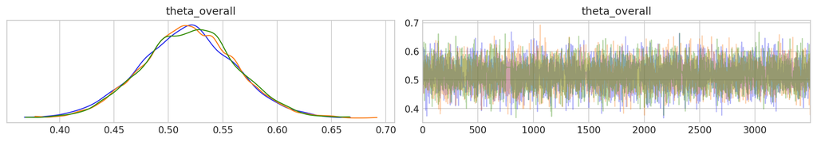

```python
az.plot_trace(idata, var_names=theta_overall, compact=False)
```

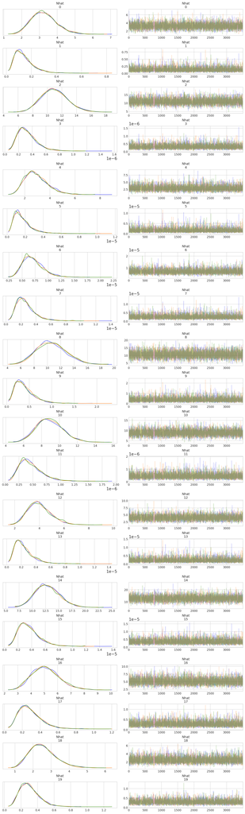

```python
az.plot_trace(idata, var_names=nhat_vars, compact=False);
```

```
array([[<Axes: title={'center': 'p_binom\nNeosphere'}>,
        <Axes: title={'center': 'p_binom\nNeosphere'}>],
       [<Axes: title={'center': 'p_binom\nHUS'}>,
        <Axes: title={'center': 'p_binom\nHUS'}>]], dtype=object)
```

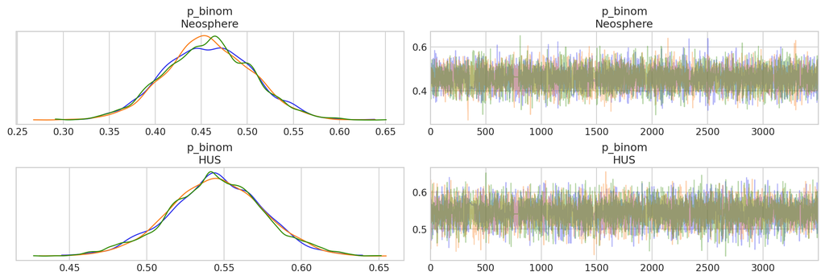

```python
az.plot_trace(idata, var_names=pCR_rate_vars, compact=False)
```

```
array([[<Axes: title={'center': 'p_diff_obs'}>,
        <Axes: title={'center': 'p_diff_obs'}>],
       [<Axes: title={'center': 'p_diff_counterfact'}>,
        <Axes: title={'center': 'p_diff_counterfact'}>]], dtype=object)
```

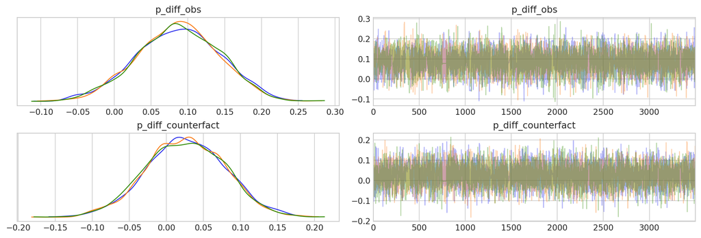

```python
az.plot_trace(idata, var_names=pCR_rate_comp_vars, compact=False)
```

```python
az.summary(idata, kind="diagnostics", var_names=core_vars)
```

|  | mcse_mean | mcse_sd | ess_bulk | ess_tail | r_hat |
| --- | --- | --- | --- | --- | --- |
| beta0 | 0.006 | 0.005 | 3461.0 | 3353.0 | 1.0 |

```python
#az.summary(idata, kind="diagnostics", var_names=group_vars)
```

```python
az.summary(idata, kind="diagnostics", var_names=effect_vars )
```

|  | mcse_mean | mcse_sd | ess_bulk | ess_tail | r_hat |
| --- | --- | --- | --- | --- | --- |
| beta_raw_Age_group_med[Under 50] | 0.010 | 0.037 | 3563.0 | 2186.0 | 1.0 |
| beta_raw_Age_group_med[50 - 77] | 0.010 | 0.037 | 4037.0 | 2188.0 | 1.0 |
| beta_raw_Age_group_med[Over 77] | 0.009 | 0.019 | 4293.0 | 3091.0 | 1.0 |
| beta_raw_Node_cytology_preop[N/A] | 0.009 | 0.013 | 3349.0 | 2904.0 | 1.0 |
| beta_raw_Node_cytology_preop[neg] | 0.006 | 0.012 | 3571.0 | 3197.0 | 1.0 |
| beta_raw_Node_cytology_preop[pos] | 0.007 | 0.011 | 3681.0 | 3411.0 | 1.0 |
| beta_raw_Tumor_size_class_preop[T1] | 0.005 | 0.006 | 3586.0 | 3389.0 | 1.0 |
| beta_raw_Tumor_size_class_preop[T2] | 0.005 | 0.005 | 3382.0 | 2944.0 | 1.0 |
| beta_raw_Tumor_size_class_preop[T3] | 0.004 | 0.007 | 5082.0 | 4023.0 | 1.0 |
| beta_raw_Tumor_size_class_preop[N/A] | 0.005 | 0.006 | 3958.0 | 3679.0 | 1.0 |
| beta_raw_hormone_status[Negative] | 0.011 | 0.017 | 4867.0 | 3857.0 | 1.0 |
| beta_raw_hormone_status[Positive] | 0.011 | 0.017 | 5191.0 | 4074.0 | 1.0 |
| beta_raw_Bilateral[False] | 0.010 | 0.022 | 3511.0 | 2719.0 | 1.0 |
| beta_raw_Bilateral[True] | 0.011 | 0.025 | 3093.0 | 2448.0 | 1.0 |
| beta_raw_NAT_discontinuation[False] | 0.012 | 0.026 | 2624.0 | 1129.0 | 1.0 |
| beta_raw_NAT_discontinuation[True] | 0.014 | 0.032 | 2625.0 | 1149.0 | 1.0 |
| beta_Age_group_med[Under 50] | 0.003 | 0.005 | 4949.0 | 3382.0 | 1.0 |
| beta_Age_group_med[50 - 77] | 0.004 | 0.005 | 3301.0 | 3296.0 | 1.0 |
| beta_Age_group_med[Over 77] | 0.007 | 0.012 | 4372.0 | 2336.0 | 1.0 |
| beta_Node_cytology_preop[N/A] | 0.006 | 0.004 | 2835.0 | 4594.0 | 1.0 |
| beta_Node_cytology_preop[neg] | 0.003 | 0.002 | 4806.0 | 5571.0 | 1.0 |
| beta_Node_cytology_preop[pos] | 0.004 | 0.002 | 3131.0 | 6090.0 | 1.0 |
| beta_Tumor_size_class_preop[T1] | 0.003 | 0.003 | 5214.0 | 5016.0 | 1.0 |
| beta_Tumor_size_class_preop[T2] | 0.003 | 0.002 | 3334.0 | 5794.0 | 1.0 |
| beta_Tumor_size_class_preop[T3] | 0.003 | 0.004 | 6778.0 | 4579.0 | 1.0 |
| beta_Tumor_size_class_preop[N/A] | 0.004 | 0.003 | 3612.0 | 5081.0 | 1.0 |
| beta_hormone_status[Negative] | 0.002 | 0.001 | 5355.0 | 7689.0 | 1.0 |
| beta_hormone_status[Positive] | 0.002 | 0.001 | 5355.0 | 7689.0 | 1.0 |
| beta_Bilateral[False] | 0.003 | 0.004 | 5810.0 | 4923.0 | 1.0 |
| beta_Bilateral[True] | 0.003 | 0.004 | 5810.0 | 4923.0 | 1.0 |
| beta_NAT_discontinuation[False] | 0.003 | 0.002 | 3885.0 | 4814.0 | 1.0 |
| beta_NAT_discontinuation[True] | 0.003 | 0.002 | 3885.0 | 4814.0 | 1.0 |

```python
az.summary(idata, kind="diagnostics", var_names=["Nhat"])
```

|  | mcse_mean | mcse_sd | ess_bulk | ess_tail | r_hat |
| --- | --- | --- | --- | --- | --- |
| Nhat[0] | 0.008 | 0.007 | 8490.0 | 7079.0 | 1.0 |
| Nhat[1] | 0.001 | 0.001 | 9569.0 | 6577.0 | 1.0 |
| Nhat[2] | 0.021 | 0.018 | 7460.0 | 6204.0 | 1.0 |
| Nhat[3] | 0.000 | 0.000 | 9108.0 | 6300.0 | 1.0 |
| Nhat[4] | 0.010 | 0.011 | 8266.0 | 6128.0 | 1.0 |
| Nhat[5] | 0.000 | 0.000 | 9495.0 | 6674.0 | 1.0 |
| Nhat[6] | 0.000 | 0.000 | 8490.0 | 6284.0 | 1.0 |
| Nhat[7] | 0.000 | 0.000 | 9015.0 | 7033.0 | 1.0 |
| Nhat[8] | 0.029 | 0.024 | 6141.0 | 2924.0 | 1.0 |
| Nhat[9] | 0.003 | 0.004 | 8667.0 | 6783.0 | 1.0 |
| Nhat[10] | 0.016 | 0.015 | 8948.0 | 5568.0 | 1.0 |
| Nhat[11] | 0.000 | 0.000 | 8657.0 | 6718.0 | 1.0 |
| Nhat[12] | 0.013 | 0.011 | 5917.0 | 2591.0 | 1.0 |
| Nhat[13] | 0.000 | 0.000 | 8547.0 | 6480.0 | 1.0 |
| Nhat[14] | 0.026 | 0.024 | 7915.0 | 6939.0 | 1.0 |
| Nhat[15] | 0.000 | 0.000 | 8468.0 | 6881.0 | 1.0 |
| Nhat[16] | 0.012 | 0.011 | 6939.0 | 1835.0 | 1.0 |
| Nhat[17] | 0.001 | 0.002 | 8774.0 | 7257.0 | 1.0 |
| Nhat[18] | 0.009 | 0.008 | 5739.0 | 1894.0 | 1.0 |
| Nhat[19] | 0.001 | 0.002 | 7180.0 | 7021.0 | 1.0 |
| Nhat[20] | 0.013 | 0.013 | 6961.0 | 6581.0 | 1.0 |
| Nhat[21] | 0.000 | 0.000 | 8932.0 | 6691.0 | 1.0 |
| Nhat[22] | 0.000 | 0.000 | 6323.0 | 2810.0 | 1.0 |
| Nhat[23] | 0.005 | 0.005 | 7522.0 | 7001.0 | 1.0 |
| Nhat[24] | 0.021 | 0.019 | 8957.0 | 7550.0 | 1.0 |
| Nhat[25] | 0.003 | 0.004 | 8586.0 | 6561.0 | 1.0 |
| Nhat[26] | 0.011 | 0.011 | 7997.0 | 7693.0 | 1.0 |
| Nhat[27] | 0.002 | 0.002 | 7652.0 | 6818.0 | 1.0 |
| Nhat[28] | 0.025 | 0.023 | 7664.0 | 6790.0 | 1.0 |
| Nhat[29] | 0.000 | 0.000 | 8707.0 | 6392.0 | 1.0 |
| Nhat[30] | 0.012 | 0.011 | 7878.0 | 7904.0 | 1.0 |
| Nhat[31] | 0.013 | 0.012 | 7732.0 | 7115.0 | 1.0 |

```python
az.summary(idata, kind="diagnostics", var_names=pCR_rate_comp_vars)
```

|  | mcse_mean | mcse_sd | ess_bulk | ess_tail | r_hat |
| --- | --- | --- | --- | --- | --- |
| p_diff_obs | 0.001 | 0.001 | 5349.0 | 3721.0 | 1.0 |
| p_diff_counterfact | 0.001 | 0.000 | 7360.0 | 6548.0 | 1.0 |

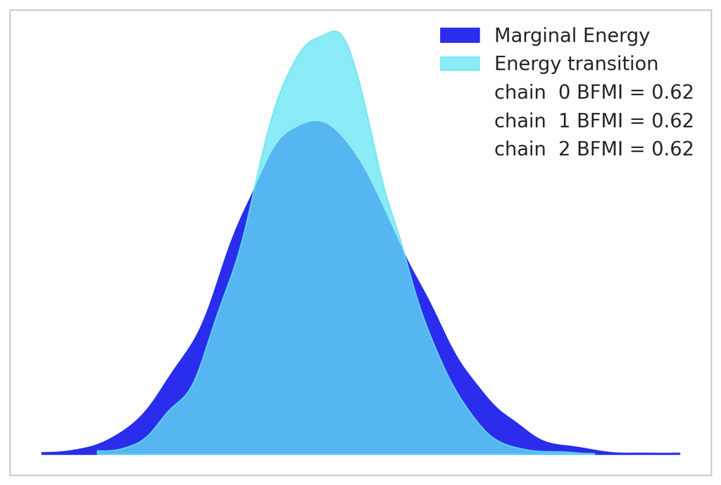

```python
az.plot_energy(idata)
```

# Model results

## The outcome model cofficients

```python
summ = az.summary(idata_paper, kind="stats", var_names=effect_vars_paper,round_to=2)
```

```python
summ
```

|  | mean | sd | hdi_3% | hdi_97% |
| --- | --- | --- | --- | --- |
| beta_age_group_med[Under 50] | 0.06 | 0.20 | -0.28 | 0.48 |
| beta_age_group_med[50 - 77] | -0.17 | 0.22 | -0.61 | 0.19 |
| beta_age_group_med[Over 77] | 0.11 | 0.34 | -0.46 | 0.84 |
| beta_node_cytology_preop[N/A] | -0.28 | 0.30 | -0.89 | 0.15 |
| beta_node_cytology_preop[neg] | 0.07 | 0.18 | -0.25 | 0.44 |
| beta_node_cytology_preop[pos] | 0.21 | 0.20 | -0.10 | 0.60 |
| beta_tumor_size_class_preop[T1] | -0.07 | 0.18 | -0.46 | 0.25 |
| beta_tumor_size_class_preop[T2] | -0.17 | 0.18 | -0.51 | 0.14 |
| beta_tumor_size_class_preop[T3] | 0.04 | 0.22 | -0.37 | 0.53 |
| beta_tumor_size_class_preop[N/A] | 0.20 | 0.23 | -0.14 | 0.67 |
| beta_hormone_status_preop[Negative] | 0.72 | 0.15 | 0.44 | 0.99 |
| beta_hormone_status_preop[Positive] | -0.72 | 0.15 | -0.99 | -0.44 |
| beta_bilateral[False] | 0.07 | 0.23 | -0.32 | 0.60 |
| beta_bilateral[True] | -0.07 | 0.23 | -0.60 | 0.32 |
| beta_NAT_discontinuation[False] | 0.17 | 0.19 | -0.12 | 0.54 |
| beta_NAT_discontinuation[True] | -0.17 | 0.19 | -0.54 | 0.12 |

```python
summ.to_latex(prefix_path + "Users/Per_Tra_analysis/Data/outcome_posterior_summary_neosphereb_discont.tex")
```

## pCR rate means for the RCT and HUS and the estimated differences, incl the difference between the HUS pCR rate and the counterfactual (corresponding the -(adf_diff)).

```python
summ_binom = az.summary(idata, kind="stats", var_names=pCR_rate_vars,round_to=2)
```

```python
summ_binom
```

|  | mean | sd | hdi_3% | hdi_97% |
| --- | --- | --- | --- | --- |
| p_binom[Neosphere] | 0.46 | 0.05 | 0.37 | 0.55 |
| p_binom[HUS] | 0.54 | 0.03 | 0.48 | 0.60 |

```python
summ_binom.to_latex(prefix_path + "Users/Per_Tra_analysis/Data/binom_posterior_summary_neosphereb_discont.tex")
```

```python
summ_deriv = az.summary(idata, kind="stats", var_names=pCR_rate_comp_vars,round_to=2)
```

```python
summ_deriv
```

|  | mean | sd | hdi_3% | hdi_97% |
| --- | --- | --- | --- | --- |
| p_diff_obs | 0.09 | 0.06 | -0.02 | 0.20 |
| p_diff_counterfact | 0.03 | 0.05 | -0.08 | 0.12 |

```python
summ_deriv.to_latex(prefix_path + "Users/Per_Tra_analysis/Data/derived_posterior_summary_neosphereb_discont.tex")
```

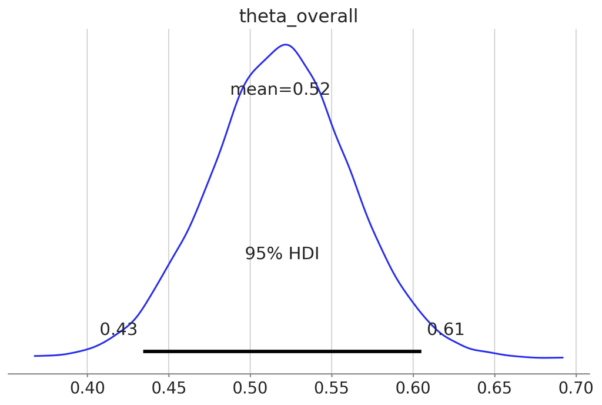

```python
az.plot_posterior(
    idata,
    var_names=["theta_overall"],
    point_estimate="mean",
    hdi_prob=0.95
)

plt.title(f"theta_overall")
plt.show()
```

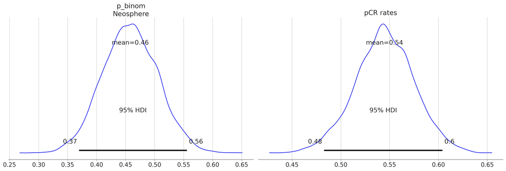

```python
az.plot_posterior(
    idata,
    var_names=pCR_rate_vars,
    point_estimate="mean",
    hdi_prob=0.95
)

plt.title(f"pCR rates")
plt.show()
```

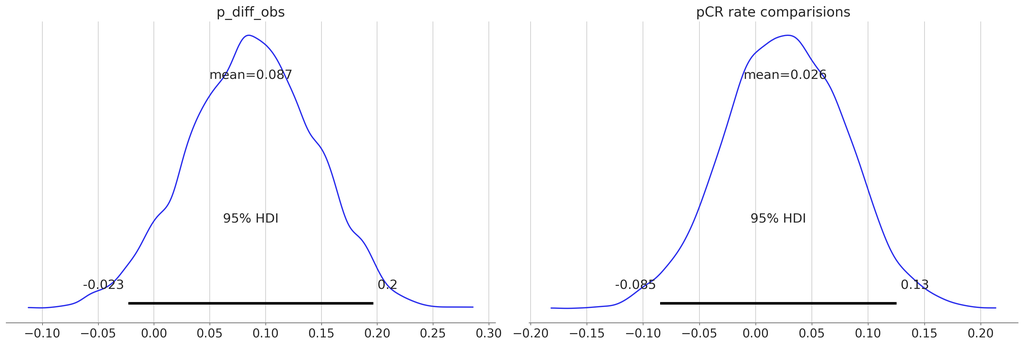

```python
az.plot_posterior(
    idata,
    var_names=pCR_rate_comp_vars,
    point_estimate="mean",
    hdi_prob=0.95
)

plt.title(f"pCR rate comparisions")
plt.show()
```

```python
p_diff_obs = idata.posterior.stack(sample=['chain', 'draw'])["p_diff_obs"]
p_diff_hus_counterfact = idata.posterior.stack(sample=['chain', 'draw'])["p_diff_counterfact"]

p_NeosphereB = idata.posterior.stack(sample=['chain', 'draw'])["p_binom"][0]
p_HUS = idata.posterior.stack(sample=['chain', 'draw'])["p_binom"][1]
p_counterfact = idata.posterior.stack(sample=['chain', 'draw'])["theta_overall"]

p_diff_counterfact_NeosphereB = p_counterfact - p_NeosphereB

print("Probability that HUS pCR rate is higher than in HelenB")
print(np.round(len(p_diff_obs[p_diff_obs>0])/len(p_diff_obs),2))
print("Probability that HUS pCR rate is higher than in RCT in practically meaningful way (more than 5%)")
print(np.round(len(p_diff_obs[p_diff_obs>0.05])/len(p_diff_obs),2))
print("Probability that RCT pCR rate is higher than in HUS")
print(np.round(len(p_diff_obs[p_diff_obs<0])/len(p_diff_obs),2))
print("Probability that RCT pCR rate is higher than in HUS in practically meaningful way (more than 5%)")
print(np.round(len(p_diff_obs[p_diff_obs<-0.05])/len(p_diff_obs),2))

print("Probability that the HUS pCR rate is higher than in countrfactual")
print(np.round(len(p_diff_hus_counterfact[p_diff_hus_counterfact>0])/len(p_diff_hus_counterfact),2))
print("Probability that the HUS pCR rate is higher than in countrfactual in practically meaningful way (more than 5%)")
print(np.round(len(p_diff_hus_counterfact[p_diff_hus_counterfact>0.05])/len(p_diff_hus_counterfact),2))
print("Probability that the counterfactual pCR rate is higher than in HUS")
print(np.round(len(p_diff_hus_counterfact[p_diff_hus_counterfact<0])/len(p_diff_hus_counterfact),2))
print("Probability that the counterfactual pCR rate is higher than in HUS in practically meaningful way (more than 5%)")
print(np.round(len(p_diff_hus_counterfact[p_diff_hus_counterfact<-0.05])/len(p_diff_hus_counterfact),2))

print("Probability that the countrfactual pCR rate is higher than in NeosphereB")
print(np.round(len(p_diff_counterfact_NeosphereB[p_diff_counterfact_NeosphereB>0])/len(p_diff_counterfact_NeosphereB),2))
print("Probability that the countrfactual pCR rate is higher than in NeosphereB in practically meaningful way (more than 5%)")
print(np.round(len(p_diff_counterfact_NeosphereB[p_diff_counterfact_NeosphereB>0.05])/len(p_diff_counterfact_NeosphereB),2))
print("Probability that the NeosphereB pCR rate is higher than in counterfactual")
print(np.round(len(p_diff_counterfact_NeosphereB[p_diff_counterfact_NeosphereB<0])/len(p_diff_counterfact_NeosphereB),2))
print("Probability that the NeosphereB pCR rate is higher than in counterfactual in practically meaningful way (more than 5%)")
print(np.round(len(p_diff_counterfact_NeosphereB[p_diff_counterfact_NeosphereB<-0.05])/len(p_diff_counterfact_NeosphereB),2))
```

```
Probability that HUS pCR rate is higher than in HelenB
0.93
Probability that HUS pCR rate is higher than in RCT in practically meaningful way (more than 5%)
0.74
Probability that RCT pCR rate is higher than in HUS
0.07
Probability that RCT pCR rate is higher than in HUS in practically meaningful way (more than 5%)
0.01
Probability that the HUS pCR rate is higher than in countrfactual
0.68
Probability that the HUS pCR rate is higher than in countrfactual in practically meaningful way (more than 5%)
0.33
Probability that the counterfactual pCR rate is higher than in HUS
0.32
Probability that the counterfactual pCR rate is higher than in HUS in practically meaningful way (more than 5%)
0.08
Probability that the countrfactual pCR rate is higher than in NeosphereB
0.83
Probability that the countrfactual pCR rate is higher than in NeosphereB in practically meaningful way (more than 5%)
0.58
Probability that the NeosphereB pCR rate is higher than in counterfactual
0.17
Probability that the NeosphereB pCR rate is higher than in counterfactual in practically meaningful way (more than 5%)
0.04
```